# Rümeysa Nazlı-121517504-Vize Ödevi

## VERİ

Bu veri seti Yüksek Lisans Programlarına başvuru sırasında önemli kabul edilen birkaç parametre içermektedir. Tahmin edilen çıktı değeri, belirli bir üniversite için öğrencilerin şansları hakkında bir fikir verir. veri seti 400 gözlem ve 9 değişkenden oluşmaktadır. Kullanılan değişkenler;

Bağımsız: GRE Scores

Bağımsız: TOEFL Scores

Bağımsız: University Rating

Bağımsız: LOR

Bağımsız: SOP

Bağımsız: Undergraduate GPA

Bağımsız: Research Experience

Bağımlı: Chance of Admit

(Not:İlk değişken olan Serial no. veride sadece sıra sayısı olup, bir anlam ifade etmediği için veriden çıkardım. Ayrıca kolay belirlenmesi için yeni veri setime ‘data’ adını verdim.)

```r
library(readr)
Admission_Predict <- read_csv("C:/Users/Lenovo/Desktop/Admission_Predict.csv")
set.seed(100)
data<-Admission_Predict
data<-data[,-1]
attach(data)

apply(data,2,function(x) sum(is.na(x)))
```

```
##      GREScore    TOEFLScore     UniRating           SOP           LOR
##             0             0             0             0             0
##          CGPA      Research ChanceofAdmit
##             0             0             0
```

Şimdi verimi max ve min değerlerine göre scale ediyorum ve scale ettiğim verimi %75 train, %25 test olacak şekilde ikiye ayırıyorum:

```r
maxs <- apply(data, 2, max)
mins <- apply(data, 2, min)

scaled <- as.data.frame(scale(data, center = mins, scale = maxs - mins))

index <- sample(1:nrow(data),round(0.75*nrow(data)))
train_ <- scaled[index,]
test_ <- scaled[-index,]
```

Train seti üzerinden lm modeli kuruyorum ve MSE değeri hesaplıyorum:

```r
lm.fit <- lm(ChanceofAdmit~., data=train_)
summary(lm.fit)
```

```
##
## Call:
## lm(formula = ChanceofAdmit ~ ., data = train_)
##
## Residuals:
##      Min       1Q   Median       3Q      Max
## -0.38025 -0.03651  0.01323  0.05820  0.23277
##
## Coefficients:
##             Estimate Std. Error t value Pr(>|t|)
## (Intercept)  0.01301    0.02060   0.632  0.52796
## GREScore     0.15703    0.05201   3.019  0.00276 **
## TOEFLScore   0.11513    0.05214   2.208  0.02800 *
## UniRating    0.05022    0.03433   1.463  0.14462
## SOP         -0.02019    0.04043  -0.499  0.61780
## LOR          0.13026    0.03991   3.264  0.00123 **
## CGPA         0.59156    0.06604   8.958  < 2e-16 ***
## Research     0.03200    0.01402   2.282  0.02320 *
## ---
## Signif. codes:  0 '***' 0.001 '**' 0.01 '*' 0.05 '.' 0.1 ' ' 1
##
## Residual standard error: 0.09605 on 292 degrees of freedom
## Multiple R-squared:  0.8146, Adjusted R-squared:  0.8101
## F-statistic: 183.2 on 7 and 292 DF,  p-value: < 2.2e-16
```

```r
pr.lm <- predict(lm.fit,test_)
MSE.lm <- sum((pr.lm - test_$ChanceofAdmit)^2)/nrow(test_)
MSE.lm
```

```
## [1] 0.01334883
```

Buradan bağımsız değişkenlerin, bağımlı değişkeni %81,46 oranında açıkladığını görüyorum. Ayrıca MSE değerimin `0.01334883` olduğunu görebilirim.

## YAPAY SİNİR AĞI MODELİ

Şimdi yapay sinir ağı modelimizi oluşturalum. Burada 2 katman ve (5,3) nöron olacak şekilde deniyorum:

```r
library(neuralnet)
```

```r
n <- names(train_)
f <- as.formula(paste("ChanceOfAdmit~", paste(n[!n %in% "ChanceOfAdmit"], collapse = " + ")))
nn <- neuralnet(data$ChanceofAdmit~.,data=train_,hidden=c(5,3),linear.output=T)
plot(nn)
```

[output not shown]

Burada regresyon modeli yaptığımız için ‘linear.output=T’ dedik. Eğer sınıflandırma olmasını isteseydik ‘linear.output=F’ olarak belirleyecektik.

Şimdi de başta scale ettiğimiz veriyi eski haline geri döndürelim ve yukarıda yaptığımız sinir ağı modeli için MSE değerini hesaplayalım:

```r
pr.nn <- compute(nn,test_[,1:7])
pr.nn_ <- pr.nn$net.result*(max(data$ChanceofAdmit)-min(data$ChanceofAdmit))+min(data$ChanceofAdmit)

MSE.nn <- sum((data[-index,]$ChanceofAdmit - pr.nn_)^2)/nrow(test_)
MSE.nn
```

```
## [1] 0.00549331
```

(5,3) nöronlu sinir ağı modelinin MSE değerini `0.00549331` buldum. Kurduğum lm modelinin MSE değerinden daha düşük bir değer elde ettim. MSE değerinin düşük olmasını istiyorum. Buradan doğru ilerlediğimi görebilirim.

## CROSS-VALIDATION İLE YAPAY SİNİR AĞI

Şimdi Yapay Sinir ağı için bir for döngüsü kullanarak hızlı bir 10 kat çapraz doğrulanmış MSE yapacağız:

```r
library(neuralnet)
library(boot)
set.seed(100)
glm.fit <- glm(ChanceofAdmit~.,data=data)
cv.glm(data,glm.fit,K=10)$delta
```

```
## [1] 0.004147605 0.004139065
```

```r
set.seed(100)
cv.error <- NULL
k <- 10

for(i in 1:k){
  index <- sample(1:nrow(data),round(0.9*nrow(data)))
  train.cv1 <- scaled[index,]
  test.cv1 <- scaled[-index,]

  nn <- neuralnet(ChanceofAdmit~.,data=train.cv1,hidden=c(5,3),linear.output=T)

  pr.nn1 <- compute(nn,test.cv1[,1:7])
  pr.nn1 <- pr.nn1$net.result*(max(data$ChanceofAdmit)-min(data$ChanceofAdmit))+min(data$ChanceofAdmit)

  test.cv.r <- (test.cv1$ChanceofAdmit)*(max(data$ChanceofAdmit)-min(data$ChanceofAdmit))+min(data$ChanceofAdmit)

  cv.error[i] <- sum((test.cv.r - pr.nn1)^2)/nrow(test.cv1)

}

cv.error
```

```
##  [1] 0.003955023 0.005261239 0.006184137 0.003924974 0.004295866
##  [6] 0.005003996 0.006955982 0.006640891 0.007489107 0.006814481
```

```r
mean(cv.error)
```

```
## [1] 0.00565257
```

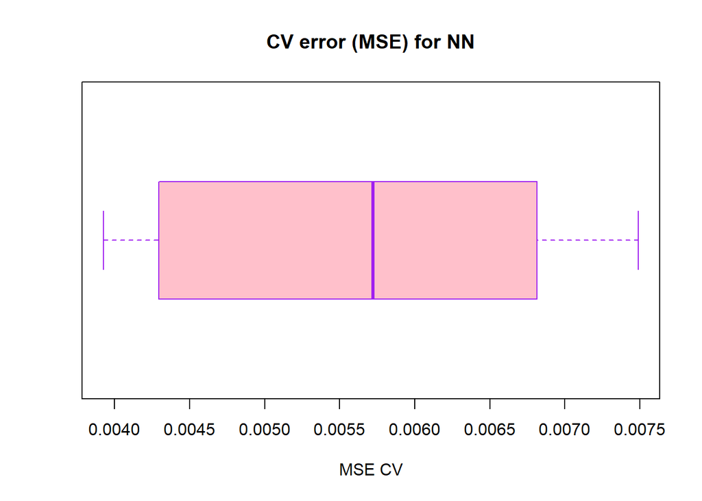

```r
boxplot(cv.error,xlab='MSE CV',col='pink',
        border='purple',names='CV error (MSE)',
        main='CV error (MSE) for NN',horizontal=TRUE)
```

Burada yaptığım işlem; veriyi rastgele olarak 10 parçaya bölüp her 10’da 1’lik parça için bir yapay sinir ağı modeli oluşturuyorum. İşlem sonunda elimde 10 adet yapay sinir ağı modeli ve bu modellerden elde ettiğim 10 MSE değeri kalıyor. Son olarak elde ettiğim bu MSE değerlerinin ortalamalarını alıyorum ve bir boxplot üzerinde görselleştiriyorum. Bulduğum ortalama MSE değeri `0.00565257` dir.

## SUPPORT VECTOR MACHINE (SVM) UYGULAMASI

Temel olarak verileri farklı sınıflara sınıflandırmak için kullanılan denetimli bir makine öğrenme algoritmasıdır. Çoğu algoritmadan farklı olarak SVM, çeşitli sınıflar arasında bir karar sınırı gibi davranan bir hiper düzlem kullanır. Dolayısıyla bu çalışmayı yapabilmek için öncelikle bağımlı değişkenimizi sınıflandırma için düzenlemeliyiz.

```r
sans=ifelse(data$ChanceofAdmit<=0.7244,"düşük","yüksek")
```

Öncelikle bağımlı değişken olan ‘ChanceOfAdmit’ değişkenini ortalamasından (0,7244) yukarısı için ‘yüksek’, aşağısı için ’düşük olarak iki gruba ayırdım.

```r
data=data.frame(data, sans)
data=data[,-8]
```

Ardından yeni ‘sans’ adındaki değişkenimi verime ekledim ve eski ‘ChanceOfAdmit’ değişkenini sildim.

```r
data$UniRating=factor(data$UniRating)
data$SOP=factor(data$SOP)
data$LOR=factor(data$LOR)
data$Research=factor(data$Research)
data$sans=factor(data$sans)

summary(data)
```

```
##     GREScore       TOEFLScore    UniRating      SOP          LOR
##  Min.   :290.0   Min.   : 92.0   1: 26     3.5    :70   3      :85
##  1st Qu.:308.0   1st Qu.:103.0   2:107     4      :70   4      :77
##  Median :317.0   Median :107.0   3:133     3      :64   3.5    :73
##  Mean   :316.8   Mean   :107.4   4: 74     4.5    :53   4.5    :45
##  3rd Qu.:325.0   3rd Qu.:112.0   5: 60     2.5    :47   2.5    :39
##  Max.   :340.0   Max.   :120.0             5      :37   2      :38
##                                            (Other):59   (Other):43
##       CGPA       Research     sans
##  Min.   :6.800   0:181    düşük :196
##  1st Qu.:8.170   1:219    yüksek:204
##  Median :8.610
##  Mean   :8.599
##  3rd Qu.:9.062
##  Max.   :9.920
##
```

```r
attach(data)
```

Veride gerekli olan değişkenleri faktöre çevirdim.

# TRAİN-TEST

```r
library(caTools)
split = sample.split(data$sans, SplitRatio = 0.80)
training_set = subset(data, split == TRUE)
test_set = subset(data, split == FALSE)
```

Burada veriyi %80 train ve %20 test olacak şekilde iki parçaya ayırdım. Ardından train seti üzerinden svm komutunu kullanarak sınıflandırma yapıyorum;

```r
library(e1071)
classifier1 = svm(formula = sans~ .,
                  data = training_set,scale=TRUE,
                  type = 'C-classification',
                  kernel='linear')
```

Şimdi de yaptığımız sınıflandırmanın test seti üzerindeki performansını ölçeceğim;

```r
y_pred = predict(classifier1, newdata = test_set[,-8])
library(caret)
confusionMatrix(table(y_pred, test_set$sans))
```

```
## Confusion Matrix and Statistics
##
##
## y_pred   düşük yüksek
##   düşük     32     10
##   yüksek     7     31
##
##                Accuracy : 0.7875
##                  95% CI : (0.6817, 0.8711)
##     No Information Rate : 0.5125
##     P-Value [Acc > NIR] : 3.552e-07
##
##                   Kappa : 0.5755
##
##  Mcnemar's Test P-Value : 0.6276
##
##             Sensitivity : 0.8205
##             Specificity : 0.7561
##          Pos Pred Value : 0.7619
##          Neg Pred Value : 0.8158
##              Prevalence : 0.4875
##          Detection Rate : 0.4000
##    Detection Prevalence : 0.5250
##       Balanced Accuracy : 0.7883
##
##        'Positive' Class : düşük
##
```

Accuracy değerim `0.7875` çıktı. Burada cost değeri yazmadığım için kod içerisinde 1 olarak belirleniyor. Cost değerini özel olarak seçebilirim. Bunun için ‘tune.out’ komutunu kullanarak 10-fold cv yöntemiyle en iyi performansı veren cost ve gamma değerlerini belirleyip daha iyi bir doğruluk yüzdesi verip vermediğini kontrol ediyorum;

```r
tune.out<-tune.svm(sans~ ., data = training_set,kernel='linear',cost=10^(-2:1), gamma=c(0.1,0.5,1))
summary(tune.out)
```

```
##
## Parameter tuning of 'svm':
##
## - sampling method: 10-fold cross validation
##
## - best parameters:
##  gamma cost
##    0.1 0.01
##
## - best performance: 0.115625
##
## - Detailed performance results:
##    gamma  cost    error dispersion
## 1    0.1  0.01 0.115625 0.05521816
## 2    0.5  0.01 0.115625 0.05521816
## 3    1.0  0.01 0.115625 0.05521816
## 4    0.1  0.10 0.115625 0.05321683
## 5    0.5  0.10 0.115625 0.05321683
## 6    1.0  0.10 0.115625 0.05321683
## 7    0.1  1.00 0.131250 0.04841229
## 8    0.5  1.00 0.131250 0.04841229
## 9    1.0  1.00 0.131250 0.04841229
## 10   0.1 10.00 0.128125 0.04528555
## 11   0.5 10.00 0.128125 0.04528555
## 12   1.0 10.00 0.128125 0.04528555
```

Çıkan sonucu incelediğimde en iyi gamma değerinin ‘0.1’ ve en iyi cost değerinin ‘0.01’ olduğunu görüyorum. Şimdi bu değerleri trains setini kullanarak svm komutu içerisinde yeniden deniyorum;

```r
library(e1071)
classifier2 = svm(formula = sans ~ .,
                  data = training_set, scale=TRUE,kernel='linear',
                  type = 'C-classification',cost= 0.01, gamma=0.1 )
```

Son olarak özel belirlediğim cost ve gamma değerleri ile oluşturduğum ikinci sınıflandırma modeli için test verisi üzerinden performansını ölçüyorum;

```r
y_pred1 = predict(classifier2, newdata = test_set[,-8])
confusionMatrix(table(y_pred1, test_set$sans))
```

```
## Confusion Matrix and Statistics
##
##
## y_pred1  düşük yüksek
##   düşük     31      7
##   yüksek     8     34
##
##                Accuracy : 0.8125
##                  95% CI : (0.7097, 0.8911)
##     No Information Rate : 0.5125
##     P-Value [Acc > NIR] : 2.438e-08
##
##                   Kappa : 0.6245
##
##  Mcnemar's Test P-Value : 1
##
##             Sensitivity : 0.7949
##             Specificity : 0.8293
##          Pos Pred Value : 0.8158
##          Neg Pred Value : 0.8095
##              Prevalence : 0.4875
##          Detection Rate : 0.3875
##    Detection Prevalence : 0.4750
##       Balanced Accuracy : 0.8121
##
##        'Positive' Class : düşük
##
```